# Section 5: Fixed-Effect Coding, Centering, and Post-Hoc Contrasts with `emmeans`

Keith Lohse, PhD, PStat

2026-07-30

Every mixed-effects model we have built so far (Sections 1-4) has ended at the omnibus test: an F-value (or a set of F-values) telling us whether a main effect or interaction is “significant.” In practice, that is rarely the end of the story, and getting the follow-up questions right turns out to depend on something we have quietly glossed over until now: how R actually represents a categorical predictor as numbers, and where a continuous predictor’s zero point sits. This section works through both of those issues in detail – because they turn out to matter more, and in a more subtle way, than “use the default and it’ll be fine” – and then introduces the package, `emmeans`, that helps us sidestep complex issues related to how we coded our variables and focus on the comparisons we care about the most.

## 5.1. Two Different Questions

Every fitted mixed model actually answers two related but distinct kinds of question, and it is worth being precise about which one you are asking at any given moment:

- **`summary(model)`** gives you individual regression coefficients ($\beta$’s) and their $t$-tests. Each coefficient is a specific, named comparison (e.g., a difference from a reference level, or a slope for one specific group) and *which* comparison it represents depends entirely on how the predictor was coded.
- **`anova(model)`** (or `car::Anova(model, type="III")`) gives you an omnibus $F$-test (or, for GLMMs, a $\chi^2$ test) for a whole term at once (e.g., “does `condition`, as a whole, matter?”) collapsing across whichever specific comparisons happen to make up that term.

You might reasonably expect the *omnibus* test, at least, to be immune to something as seemingly cosmetic as how a factor’s levels are coded. That expectation turns out to be only partly right, and the ways it fails causes real, reproducible confusion when a mixed-effects model doesn’t match what a repeated-measures ANOVA would have said, or when adding a covariate to a model unexpectedly changes an unrelated-looking $p$-value.

## 5.2. How R Codes Categorical Predictors

By default, R represents an unordered factor using **treatment (dummy) coding**: one level is chosen as the reference (alphabetically first, unless you say otherwise), and every other level gets a column that is 1 for that level and 0 everywhere else. This is what has been happening, invisibly, in every model we’ve fit so far. Two alternatives come up constantly enough to be worth naming:

- **Sum (effects) coding** (`contr.sum`): each non-reference level is coded relative to the *grand mean* rather than to one specific reference level, and the coefficients sum to zero across levels.
- **Polynomial (orthogonal) coding** (`contr.poly`): built for **ordered** factors, decomposing the factor’s effect into linear, quadratic, cubic, etc. trend components. This is R’s own default for any factor you explicitly declare with `factor(..., ordered = TRUE)` – R’s global `options("contrasts")` setting is actually a *pair*, `c("contr.treatment", "contr.poly")`: the first element governs unordered factors, the second governs ordered ones. You get polynomial contrasts automatically for an ordered factor without changing anything.

All of these coding schemes describe the *same* fitted regression surface (i.e., they are just different bases for representing the same set of group differences) so it’s natural to assume the choice among them is purely cosmetic. But it gets more complicated than that…

## 5.3. Does the Coding Scheme Change the Omnibus Test?

We’ll use the mixed-factorial model we already built in Section 3, Part 3 (`mod3 <- lmer(speed ~ age_group*condition + (1|subID), data=data_COND)`), refit under both coding schemes.

```r
library(tidyverse)
library(lme4)
library(lmerTest)
library(car)
library(emmeans)
```

```r
DATA <- read.csv("https://raw.githubusercontent.com/keithlohse/mixed_effects_models/master/data_AGING_example.csv",
                 stringsAsFactors = TRUE)
data_COND <- DATA %>% group_by(subID, condition, age_group, group) %>%
  summarize(speed = mean(speed, na.rm = TRUE), .groups = "drop") %>%
  arrange(age_group, subID, condition)
```

```r
options(contrasts = c("contr.treatment", "contr.poly"))  # R's default
mod3_treat <- lmer(speed ~ age_group*condition + (1|subID), data = data_COND, REML = TRUE)

options(contrasts = c("contr.sum", "contr.poly"))
mod3_sum <- lmer(speed ~ age_group*condition + (1|subID), data = data_COND, REML = TRUE)

cat("Treatment coding, lmerTest::anova():\n")
```

```
## Treatment coding, lmerTest::anova():
```

```r
anova(mod3_treat)
```

|  | Sum Sq | Mean Sq | NumDF | DenDF | F value | Pr(>F) |
| --- | --- | --- | --- | --- | --- | --- |
| age_group | 0.24387434 | 0.24387434 | 1 | 38 | 47.176032 | 3.706668e-08 |
| condition | 0.28195510 | 0.14097755 | 2 | 76 | 27.271263 | 1.181245e-09 |
| age_group:condition | 0.05667469 | 0.02833734 | 2 | 76 | 5.481689 | 5.972183e-03 |

```r
cat("\nSum coding, lmerTest::anova():\n")
```

```
##
## Sum coding, lmerTest::anova():
```

```r
anova(mod3_sum)
```

|  | Sum Sq | Mean Sq | NumDF | DenDF | F value | Pr(>F) |
| --- | --- | --- | --- | --- | --- | --- |
| age_group | 0.24387434 | 0.24387434 | 1 | 38 | 47.176032 | 3.706668e-08 |
| condition | 0.28195510 | 0.14097755 | 2 | 76 | 27.271263 | 1.181245e-09 |
| age_group:condition | 0.05667469 | 0.02833734 | 2 | 76 | 5.481689 | 5.972183e-03 |

These match exactly, for every term, down to the decimal. That’s reassuring, and it’s the result we’ve implicitly been relying on every time we’ve run `anova()` in this repository so far. But watch what happens if we ask the same question a different way, using `car::Anova(type = "III")` instead of `lmerTest::anova()` – a function we already used alongside `anova()` back in Section 2:

```r
cat("Treatment coding, car::Anova(type=3):\n")
```

```
## Treatment coding, car::Anova(type=3):
```

```r
car::Anova(mod3_treat, type = 3, test.statistic = "F")
```

|  | F | Df | Df.res | Pr(>F) |
| --- | --- | --- | --- | --- |
| (Intercept) | 689.500462 | 1 | 62.99267 | 1.232252e-35 |
| age_group | 57.147628 | 1 | 62.99267 | 2.105232e-10 |
| condition | 27.809108 | 2 | 76.00000 | 8.647856e-10 |
| age_group:condition | 5.481689 | 2 | 76.00000 | 5.972183e-03 |

```r
cat("\nSum coding, car::Anova(type=3):\n")
```

```
##
## Sum coding, car::Anova(type=3):
```

```r
car::Anova(mod3_sum, type = 3, test.statistic = "F")
```

|  | F | Df | Df.res | Pr(>F) |
| --- | --- | --- | --- | --- |
| (Intercept) | 3001.012722 | 1 | 38 | 9.031437e-38 |
| age_group | 47.176029 | 1 | 38 | 3.706669e-08 |
| condition | 27.271263 | 2 | 76 | 1.181245e-09 |
| age_group:condition | 5.481689 | 2 | 76 | 5.972183e-03 |

Now `age_group` is genuinely different: F = 57.15 under treatment coding, F = 47.18 under sum coding – and the sum-coded number is the one that agrees with `lmerTest::anova()` above. This is not a small-sample or unbalanced-data artifact, either – `data_COND` is a perfectly balanced design (20 subjects per age group, equal cell sizes throughout), and the discrepancy still shows up. The reason is structural, not statistical: `car::Anova(type=3)`’s test for a lower-order term (like the main effect of `age_group`) is computed by dropping that term’s columns while holding the interaction’s columns fixed – and because the interaction’s columns are literally built by multiplying the main-effect columns together, *how* those main-effect columns were coded changes what “holding the interaction fixed” even means. Treatment coding’s columns are not centered (a reference level is coded 0, not $-0.5$), so they don’t have the orthogonality property that makes this comparison well-behaved; sum and polynomial coding’s columns do.

`lmerTest::anova()` computes its Type III test in a way that sidesteps the problem of how categorical factors are coded by effectively recoding our *categorical* factors “under the hood” based on the underlying cell-means structure. This is why our `anova()` outputs agreed regardless of coding and why nothing in Sections 1-4 broke despite never touching the default contrasts. When we switched to `car::Anova()` for out ANOVA tables, however, there is no implicit recoding of the categorical factors and the omnibus tests are sensitive to how we coded the variables.

Additionally, if you introduce any imbalance into `data_COND` (unequal group sizes, missing cells), `lmerTest::anova()` continues to agree with itself under either coding scheme, while `car::Anova(type=3)` continues to require sum-style contrasts to match it. So the practical rule for *categorical* predictors is narrower than “always change your contrasts or everything breaks”: it’s specifically that **`car::Anova(type="III")` needs sum (or polynomial) contrasts to agree with what a factorial ANOVA – or `lmerTest::anova()` – would say**, whenever an interaction is present. If you only ever use `lmerTest::anova()` for your omnibus tests, as this repository has so far, you have been safe by accident. It’s worth setting sum contrasts anyway, both for this reason and because (as we’ll see next) the coding of *categorical* factors does nothing to how *continuous* variables are represented in the model.

## 5.4. Continuous Covariates: Centering Matters Even More

Contrast coding is a question specifically about *categorical* factors. A different, and in practice more consequential, version of the same underlying issue shows up whenever a *continuous* covariate is involved in an interaction – and no amount of `options(contrasts=)` fixes it, because there’s no factor and no contrast scheme involved at all. The relevant choice here is simply: where does the continuous variable’s zero point sit?

To see how much this matters, we’ll simulate a small Group x Time growth-curve design – structurally identical to the models we built in Section 2, without any centering applied yet.

```r
set.seed(99)
n_sub <- 40
df_gt <- expand.grid(subID = factor(1:n_sub), time = 1:4) %>%
  mutate(group = factor(if_else(as.numeric(subID) <= n_sub/2, "Control", "Treatment")))

sub_rfx <- rnorm(n_sub, 0, 2); names(sub_rfx) <- levels(df_gt$subID)
df_gt <- df_gt %>%
  mutate(score = 10 + 0.5*time + 2*(group=="Treatment") + 1.2*time*(group=="Treatment") +
           sub_rfx[subID] + rnorm(n(), 0, 1),
         time.c = time - mean(time))

options(contrasts = c("contr.treatment", "contr.poly"))  # Group's coding is held fixed throughout
```

```r
m_uncentered <- lmer(score ~ group * time   + (1 + time   | subID), data = df_gt)
```

```
## boundary (singular) fit: see help('isSingular')
```

```r
m_centered   <- lmer(score ~ group * time.c + (1 + time.c | subID), data = df_gt)
```

```
## boundary (singular) fit: see help('isSingular')
```

```r
cat("Uncentered time, lmerTest::anova():\n")
```

```
## Uncentered time, lmerTest::anova():
```

```r
anova(m_uncentered)
```

|  | Sum Sq | Mean Sq | NumDF | DenDF | F value | Pr(>F) |
| --- | --- | --- | --- | --- | --- | --- |
| group | 14.87851 | 14.87851 | 1 | 39.23531 | 16.26833 | 2.460143e-04 |
| time | 267.73240 | 267.73240 | 1 | 117.37855 | 292.74166 | 1.124056e-33 |
| group:time | 50.13729 | 50.13729 | 1 | 117.37855 | 54.82069 | 2.182239e-11 |

```r
cat("\nCentered time.c, SAME Group coding, lmerTest::anova():\n")
```

```
##
## Centered time.c, SAME Group coding, lmerTest::anova():
```

```r
anova(m_centered)
```

|  | Sum Sq | Mean Sq | NumDF | DenDF | F value | Pr(>F) |
| --- | --- | --- | --- | --- | --- | --- |
| group | 62.53763 | 62.53763 | 1 | 38.0000 | 68.37928 | 5.068918e-10 |
| time.c | 267.73236 | 267.73236 | 1 | 117.3784 | 292.74129 | 1.124165e-33 |
| group:time.c | 50.13728 | 50.13728 | 1 | 117.3784 | 54.82062 | 2.182304e-11 |

Group’s coding never changed between these two models – it’s treatment coding both times. The *only* thing that changed is where `time` sits relative to zero, and the `group` test swings from F = 16.27 to F = 68.38. `time` and `group:time`, meanwhile, are identical in both models. We can see exactly why by looking at the correlation among the fixed-effect estimates:

```r
cat("Uncentered model:\n")
```

```
## Uncentered model:
```

```r
round(cov2cor(vcov(m_uncentered)), 3)
```

```
## 4 x 4 Matrix of class "corMatrix"
##                     (Intercept) groupTreatment   time groupTreatment:time
## (Intercept)               1.000         -0.707 -0.471               0.333
## groupTreatment           -0.707          1.000  0.333              -0.471
## time                     -0.471          0.333  1.000              -0.707
## groupTreatment:time       0.333         -0.471 -0.707               1.000
```

```r
cat("\nCentered model:\n")
```

```
##
## Centered model:
```

```r
round(cov2cor(vcov(m_centered)), 3)
```

```
## 4 x 4 Matrix of class "corMatrix"
##                       (Intercept) groupTreatment time.c groupTreatment:time.c
## (Intercept)                 1.000         -0.707 -0.034                 0.024
## groupTreatment             -0.707          1.000  0.024                -0.034
## time.c                     -0.034          0.024  1.000                -0.707
## groupTreatment:time.c       0.024         -0.034 -0.707                 1.000
```

In the uncentered model, `group` and `group:time` are correlated at $-0.47$; after centering, that drops to $-0.03$. Uncentered, `time` never crosses zero, so the interaction column (`group` $\times$ `time`) is nearly a rescaled copy of the plain `group` column for any given subject – the two terms are fighting over the same variance, and the model can no longer cleanly attribute it to one or the other. This is precisely the collinearity mechanism discussed in Section 9’s diagnostics chapter, just showing up directly in an ANOVA table instead of a VIF number.

This is not only a simulated-data phenomenon. Go back to Section 2’s own SCI data, which already builds *two* versions of the time variable – `year.0` (shifted so the first assessment is at time 0) and `year.c` (mean-centered via `scale()`).

```r
DAT2 <- read.csv("https://raw.githubusercontent.com/keithlohse/mixed_effects_models/master/data_SCI_longitudinal_example.csv",
                 stringsAsFactors = TRUE)
DAT2$year.0 <- (DAT2$time - 1) / 12
DAT2$year.c <- as.numeric(scale(DAT2$time, scale = FALSE))

m_yr0 <- lmer(rasch_FIM ~ year.0 * AIS_grade + (1 + year.0 | subID), data = DAT2, REML = FALSE,
              control = lmerControl(optimizer = "bobyqa", optCtrl = list(maxfun = 5e5)))
m_yrc <- lmer(rasch_FIM ~ year.c * AIS_grade + (1 + year.c | subID), data = DAT2, REML = FALSE,
              control = lmerControl(optimizer = "bobyqa", optCtrl = list(maxfun = 5e5)))

cat("year.0 (baseline-referenced), AIS_grade F-test:\n")
```

```
## year.0 (baseline-referenced), AIS_grade F-test:
```

```r
anova(m_yr0)["AIS_grade", ]
```

|  | Sum Sq | Mean Sq | NumDF | DenDF | F value | Pr(>F) |
| --- | --- | --- | --- | --- | --- | --- |
| AIS_grade | 1799.554 | 899.7771 | 2 | 39.86491 | 25.36188 | 7.841814e-08 |

```r
cat("\nyear.c (mean-centered), AIS_grade F-test:\n")
```

```
##
## year.c (mean-centered), AIS_grade F-test:
```

```r
anova(m_yrc)["AIS_grade", ]
```

|  | Sum Sq | Mean Sq | NumDF | DenDF | F value | Pr(>F) |
| --- | --- | --- | --- | --- | --- | --- |
| AIS_grade | 1772.126 | 886.0629 | 2 | 39.99983 | 24.97532 | 9.143736e-08 |

## 5.5. Why This Happens, and What to Do About It

Step back from the mechanics for a moment. What does “the main effect of Group” even mean, in a model that also contains a Group x Time interaction? Read literally, a Type III test of a lower-order term is asking: *does removing this term change the fit, holding the interaction fixed?* But “holding the interaction fixed” is only a well-posed question once you’ve fixed *where* the other variable in that interaction is sitting – at its reference level (if categorical) or at some specific value (if continuous). Treatment coding implicitly answers “at the reference level”; an uncentered continuous covariate implicitly answers “at zero,” wherever that happens to fall. Neither of those is a *wrong* answer, exactly – they’re perfectly valid, specific questions – but they are only sometimes the question that researchers want to ask. That is, researchers are often interested in *main effects* and *interactions*, not *simple effects* and interactions.

- A *main effect* asks about the effect of Variable A on average across all levels of Variable B – e.g., “does Group matter, on average, across the full range of Time we actually studied?” When Time is centered around it’s own mean and there is a Group x Time interaction in the model, then the effect of Group is “on average” across time because on average is when `Time = 0`.
- A *simple effect asks about the effect of Variable A at a specific level of Variable B – e.g, “does Group matter at the very first observation at the beginning of our study?” If the first observation is coded as 0 and a Group x Time interaction is included in the model, then the effect of Group is “at the beginning” because the intercept is when `Time = 0`.

Two practical habits follow directly from this:

1. **For unordered categorical factors**, set sum contrasts (`contr.sum`) rather than relying on the default. For genuinely **ordered** categorical factors with a small number of discrete levels (a 3-level dose, a small number of trial blocks treated as a factor), `contr.poly` is an even better choice, since polynomial contrasts are automatically mean-centered *and* mutually orthogonal – it solves both problems in this section at once, for that variable. In practice, that means setting:

   ```r
   options(contrasts = c("contr.sum", "contr.poly"))
   ```

   which changes nothing for the omnibus tests you get from `lmerTest::anova()` (as we saw above), but *does* matter the moment you use `car::Anova()`, and makes every individual `summary()` coefficient a deviation from the grand mean rather than from an arbitrary reference level – generally the more useful default for interpretation once interactions are involved.
2. **For continuous covariates that appear in any interaction**, mean-center them explicitly (or choose some other meaningful, deliberate reference point) rather than leaving them on their raw scale. This is not something any `options()` setting can do for you, because there’s no factor and no contrast scheme involved – it has to happen in your data, as `year.0`/`year.c`/`time.c` already do throughout this repository. Do this by habit, before a diagnostic tool (like Section 9’s `check_collinearity()`) has to catch it for you.

## 5.6. The Escape Hatch: Let `emmeans` do linear algebra for you!

Fortunately, there a clean way to handle all of these issues, and it’s the reason this section exists. Instead of agonizing over how your coding and centering choices line up with the specific question you meant to ask, you can just ask the question directly, at a value (or averaged over values) that you name yourself. That is exactly what `emmeans` (for categorical predictors and factor levels) and its companion `emtrends` (for the *slope* of a continuous predictor) do – and because they work directly from the fitted regression surface rather than from any particular parameterization of it, they give the same answer regardless of how you coded or centered anything.

*To be clear* coding and centering are critically important to make sure we are getting the main-effects/interactions we want in an ANOVA table, or to make sure we are interpreting `summary()` output correctly. But regardless of the codes we used, we can always recover specific comparisons we want using `emmeans`.`

We can check this directly, reusing the two Group x Time models we just built, which disagreed so sharply on their omnibus `group` test:

```r
cat("Slope of time within each group -- UNCENTERED model:\n")
```

```
## Slope of time within each group -- UNCENTERED model:
```

```r
emtrends(m_uncentered, ~ group, var = "time")
```

```
##  group     time.trend     SE df lower.CL upper.CL
##  Control        0.657 0.0957 38    0.463     0.85
##  Treatment      1.659 0.0957 38    1.465     1.85
##
## Degrees-of-freedom method: kenward-roger
## Confidence level used: 0.95
```

```r
cat("\nSlope of time within each group -- CENTERED model:\n")
```

```
##
## Slope of time within each group -- CENTERED model:
```

```r
emtrends(m_centered, ~ group, var = "time.c")
```

```
##  group     time.c.trend     SE df lower.CL upper.CL
##  Control          0.657 0.0957 38    0.463     0.85
##  Treatment        1.659 0.0957 38    1.465     1.85
##
## Degrees-of-freedom method: kenward-roger
## Confidence level used: 0.95
```

```r
cat("Predicted score for each group AT time = 4 -- UNCENTERED model:\n")
```

```
## Predicted score for each group AT time = 4 -- UNCENTERED model:
```

```r
emmeans(m_uncentered, ~ group, at = list(time = 4))
```

```
## NOTE: Results may be misleading due to involvement in interactions
```

```
##  group     emmean    SE df lower.CL upper.CL
##  Control     11.5 0.495 38     10.5     12.5
##  Treatment   18.6 0.495 38     17.6     19.6
##
## Degrees-of-freedom method: kenward-roger
## Confidence level used: 0.95
```

```r
cat("\nPredicted score for each group AT the same real point -- CENTERED model:\n")
```

```
##
## Predicted score for each group AT the same real point -- CENTERED model:
```

```r
emmeans(m_centered, ~ group, at = list(time.c = 4 - mean(1:4)))
```

```
## NOTE: Results may be misleading due to involvement in interactions
```

```
##  group     emmean    SE df lower.CL upper.CL
##  Control     11.5 0.495 38     10.5     12.5
##  Treatment   18.6 0.495 38     17.6     19.6
##
## Degrees-of-freedom method: kenward-roger
## Confidence level used: 0.95
```

## 5.7. A Quick Note on Degrees of Freedom

Because mixed-effects models don’t have a single, clean residual degrees of freedom the way ordinary regression does (see the discussion of the Satterthwaite approximation in Section 1 and Section 3), every post-hoc test built on top of a mixed model has to make the same choice that the omnibus test did. `emmeans` gives you the same two options we’ve already seen:

- **Satterthwaite**: the default in `lmerTest`, computationally cheap, and the same approximation you’ve already seen in Sections 1-4.
- **Kenward-Roger**: adjusts the covariance matrix of the fixed effects for small-sample bias in addition to adjusting the degrees of freedom, which makes it a somewhat more conservative (and more computationally expensive) choice. It requires the `pbkrtest` package, which `emmeans` and `lmerTest` will use automatically if it is installed.

For a single model, the two will typically agree quite closely; the difference matters most in small samples with a lot of missing data or unbalanced cell sizes.

## 5.8. A Worked Example: A 2 (Group) x 3 (Time) Design

To practice the mechanics of `emmeans` itself, we will simulate one more small data set: a hypothetical randomized controlled trial in which 50 participants (25 Control, 25 Treatment) were measured at three time points (Pre, Post, and a Followup session). This is a deliberately “clean,” fully-balanced design, distinct from the continuous-time example above, so that the reference-grid ordering and the custom-contrast weights below are easy to see.

```r
options(contrasts = c("contr.sum", "contr.poly"))

set.seed(42)
n_per_group <- 25
subjects <- factor(1:(n_per_group * 2))

df_emmeans <- expand.grid(
  subID = subjects,
  time  = factor(c("Pre", "Post", "Followup"), levels = c("Pre", "Post", "Followup"))
) %>%
  mutate(
    group = factor(if_else(as.numeric(subID) <= n_per_group, "Control", "Treatment"))
  )

sub_rfx <- rnorm(n_per_group * 2, mean = 0, sd = 2.0)
names(sub_rfx) <- levels(subjects)

df_emmeans <- df_emmeans %>%
  mutate(
    time_eff = case_when(time == "Pre" ~ 0, time == "Post" ~ -1.5, time == "Followup" ~ -2.0),
    grp_eff  = if_else(group == "Treatment", 0.5, -0.5),
    int_eff  = case_when(
      group == "Treatment" & time == "Post" ~ -2.5,
      group == "Treatment" & time == "Followup" ~ -3.5,
      TRUE ~ 0
    ),
    score = 10 + time_eff + grp_eff + int_eff + sub_rfx[subID] + rnorm(n(), 0, 1.2)
  )
```

```r
model_f5 <- lmer(score ~ group * time + (1 | subID), data = df_emmeans, REML = TRUE)

# Omnibus Type III test, using Kenward-Roger degrees of freedom this time for variety
anova(model_f5, type = 3, ddf = "Kenward-Roger")
```

|  | Sum Sq | Mean Sq | NumDF | DenDF | F value | Pr(>F) |
| --- | --- | --- | --- | --- | --- | --- |
| group | 10.96580 | 10.96580 | 1 | 48 | 8.636237 | 5.053047e-03 |
| time | 420.64478 | 210.32239 | 2 | 96 | 165.641781 | 7.492768e-32 |
| group:time | 78.58853 | 39.29426 | 2 | 96 | 30.946642 | 4.241931e-11 |

The Group x Time interaction is significant, which tells us the Treatment effect is not constant across time – but it doesn’t tell us *where* the groups start to differ. That’s where `emmeans` comes in.

## 5.9. Estimated Marginal Means

```r
emm_int <- emmeans(model_f5, ~ group * time, lmer.df = "Kenward-Roger")
emm_int
```

```
##  group     time     emmean    SE   df lower.CL upper.CL
##  Control   Pre       10.05 0.505 63.1     9.04    11.05
##  Treatment Pre       10.05 0.505 63.1     9.04    11.06
##  Control   Post       8.21 0.505 63.1     7.20     9.21
##  Treatment Post       5.79 0.505 63.1     4.78     6.80
##  Control   Followup   7.87 0.505 63.1     6.87     8.88
##  Treatment Followup   4.43 0.505 63.1     3.42     5.43
##
## Degrees-of-freedom method: kenward-roger
## Confidence level used: 0.95
```

This table is the heart of everything that follows: it is the model’s best estimate of the mean score in each of the six Group x Time cells, each with its own standard error and confidence interval, all computed on a balanced grid directly from `model_f5`’s fixed effects (marginalizing over the random intercept for subject). Every contrast we compute below is just a weighted combination of these six numbers.

## 5.10. Pairwise Post-Hoc Comparisons

### 5.10.1 All Pairwise Comparisons (Tukey-Corrected)

If we genuinely want to compare every cell to every other cell (all $\binom{6}{2}=15$ pairs), we should control the familywise error rate across all 15 tests. The Tukey HSD adjustment is the reasonable choice for this “compare everything to everything” situation:

```r
pairs_all <- contrast(emm_int, method = "pairwise", adjust = "tukey")
summary(pairs_all)
```

|  | contrast | estimate | SE | df | t.ratio | p.value |
| --- | --- | --- | --- | --- | --- | --- |
| 1 | Control Pre - Treatment Pre | -0.006269091 | 0.7135935 | 63.112 | -0.00878524 | 1.000000e+00 |
| 2 | Control Pre - Control Post | 1.840782440 | 0.3187152 | 96.000 | 5.77563397 | 1.395569e-06 |
| 3 | Control Pre - Treatment Post | 4.257634474 | 0.7135935 | 63.112 | 5.96647002 | 1.765408e-06 |
| 4 | Control Pre - Control Followup | 2.172473941 | 0.3187152 | 96.000 | 6.81634832 | 1.271612e-08 |
| 5 | Control Pre - Treatment Followup | 5.619859541 | 0.7135935 | 63.112 | 7.87543499 | 8.837361e-10 |
| 6 | Treatment Pre - Control Post | 1.847051530 | 0.7135935 | 63.112 | 2.58838039 | 1.152763e-01 |
| 7 | Treatment Pre - Treatment Post | 4.263903565 | 0.3187152 | 96.000 | 13.37841221 | 4.281233e-10 |
| 8 | Treatment Pre - Control Followup | 2.178743031 | 0.7135935 | 63.112 | 3.05319892 | 3.722165e-02 |
| 9 | Treatment Pre - Treatment Followup | 5.626128632 | 0.3187152 | 96.000 | 17.65252587 | 4.281229e-10 |
| 10 | Control Post - Treatment Post | 2.416852035 | 0.7135935 | 63.112 | 3.38687487 | 1.481205e-02 |

[output cut: 5 more lines]

Fifteen tests is a lot to look at, and most of them are not actually questions we set out to ask (do we really care whether Control-Pre differs from Treatment-Followup?). In practice, a more targeted set of comparisons – driven by our actual hypotheses – is usually more useful, and lets us use a less conservative correction because we are testing fewer, more specific things (e.g., see my video on stategies for post-hoc testing: https://www.youtube.com/watch?v=Qr1hxsMIGck).

### 5.10.2 Simple Effects: Comparing Groups at Each Time Point

Our first real question is: at which time point(s) do Control and Treatment actually differ? This calls for comparing `group` *within* each level of `time` – what is often called a test of **simple effects**. We ask `emmeans` for this directly with the `|` (conditioning) operator:

```r
emm_by_time <- emmeans(model_f5, ~ group | time)
pairs_by_time <- pairs(emm_by_time, adjust = "sidak")
pairs_by_time
```

```
## time = Pre:
##  contrast            estimate    SE   df t.ratio p.value
##  Control - Treatment -0.00627 0.714 63.1  -0.009  0.9930
##
## time = Post:
##  contrast            estimate    SE   df t.ratio p.value
##  Control - Treatment  2.41685 0.714 63.1   3.387  0.0012
##
## time = Followup:
##  contrast            estimate    SE   df t.ratio p.value
##  Control - Treatment  3.44739 0.714 63.1   4.831  <.0001
##
## Degrees-of-freedom method: kenward-roger
```

Because we are only running three tests here (one per time point), the Sidak correction – slightly less conservative than Tukey’s HSD – is a reasonable choice, appropriate for a small pre-specified family of comparisons. The pattern is exactly what the interaction term predicted: the groups do not differ at baseline (as they shouldn’t, since participants were randomized before treatment began), and a Control-Treatment gap opens up by the Post assessment and grows larger by Followup.

### 5.10.3 Simple Effects: Comparing Time Points Within Each Group

We can just as easily flip the conditioning around and ask whether each group changes over time on its own:

```r
emm_by_group <- emmeans(model_f5, ~ time | group)
pairs_by_group <- pairs(emm_by_group, adjust = "holm")
pairs_by_group
```

```
## group = Control:
##  contrast        estimate    SE df t.ratio p.value
##  Pre - Post         1.841 0.319 96   5.776  <.0001
##  Pre - Followup     2.172 0.319 96   6.816  <.0001
##  Post - Followup    0.332 0.319 96   1.041  0.3006
##
## group = Treatment:
##  contrast        estimate    SE df t.ratio p.value
##  Pre - Post         4.264 0.319 96  13.378  <.0001
##  Pre - Followup     5.626 0.319 96  17.653  <.0001
##  Post - Followup    1.362 0.319 96   4.274  <.0001
##
## Degrees-of-freedom method: kenward-roger
## P value adjustment: holm method for 3 tests
```

Here we’ve used the Holm correction instead of Sidak, mostly to illustrate that `emmeans` supports several standard adjustment methods (`"tukey"`, `"sidak"`, `"holm"`, `"bonferroni"`, `"fdr"`, and `"none"` among others) and you should pick the one that matches how conservative you want to be, not just default to whichever one you saw in the last paper you read. Personally, I err on the side of not correcting, *but* transparently reporting all tests (see: Rothman, 1990; Hoffman et al., 2026). I like this approach because it allows readers to decide how conservative they want to be, but that sort of subjectivity is not always desirable when statistical significance is being employed for decision making.

## 5.11. Custom Contrasts

Sometimes none of the “off-the-shelf” comparisons above are quite the question we actually want to ask. Suppose our real, pre-registered hypothesis was narrower than “do all time points differ”: we specifically expected that **the Treatment group’s Followup score would be lower than the average of its own Pre and Post scores** (i.e., that any initial treatment gains would be maintained, not reversed, by Followup). We can build that exact contrast by hand.

The key to writing a custom contrast is knowing the *order* that `emm_int` lists its cells in, because that is the order your weights need to line up with:

```r
emm_int
```

```
##  group     time     emmean    SE   df lower.CL upper.CL
##  Control   Pre       10.05 0.505 63.1     9.04    11.05
##  Treatment Pre       10.05 0.505 63.1     9.04    11.06
##  Control   Post       8.21 0.505 63.1     7.20     9.21
##  Treatment Post       5.79 0.505 63.1     4.78     6.80
##  Control   Followup   7.87 0.505 63.1     6.87     8.88
##  Treatment Followup   4.43 0.505 63.1     3.42     5.43
##
## Degrees-of-freedom method: kenward-roger
## Confidence level used: 0.95
```

The grid above lists the six cells in this order: Control-Pre, Treatment-Pre, Control-Post, Treatment-Post, Control-Followup, Treatment-Followup. Our hypothesis only involves the Treatment group, so every “Control” cell gets a weight of 0, and we want:
$$\text{Treatment-Followup} -
\tfrac{1}{2}(\text{Treatment-Pre} + \text{Treatment-Post})$$
which means Treatment-Pre and Treatment-Post each get a weight of $-0.5$, and Treatment-Followup gets a weight of $+1$ (weights that define a contrast should always sum to 0):

```r
custom_contrast_list <- list(
  "Trt_Followup_vs_PrePostAvg" = c(0, -0.5, 0, -0.5, 0, 1)
)
contrast(emm_int, custom_contrast_list)
```

```
##  contrast                   estimate    SE df t.ratio p.value
##  Trt_Followup_vs_PrePostAvg    -3.49 0.276 96 -12.659  <.0001
##
## Degrees-of-freedom method: kenward-roger
```

**A word of caution.** It is very easy to get a weight vector like this subtly wrong – swapping two adjacent weights, or forgetting that a level was dropped – and `contrast()` will not warn you, because from `emmeans`’s point of view any vector that sums to zero is a perfectly legitimate contrast; it has no way of knowing that isn’t the comparison you meant to ask about. Always print the reference grid immediately before writing your weights (as we did above) and double check your arithmetic against a hand calculation for at least one case. Here, for instance, we can confirm the estimate above by pulling the two Treatment-group means directly out of `emm_int` and subtracting by hand:

```r
emm_df <- as.data.frame(emm_int)
trt <- emm_df[emm_df$group == "Treatment", ]
trt$emmean[trt$time == "Followup"] - mean(trt$emmean[trt$time %in% c("Pre", "Post")])
```

```
## [1] -3.494177
```

## 5.12. Visualizing Estimated Marginal Means

A table of EMMs is useful, but a plot usually communicates the interaction pattern faster than any table can. `emmeans` provides `emmip()` (EMM interaction plot) for exactly this purpose, built on top of `ggplot2` so that it can be extended with the usual `ggplot2` layers:

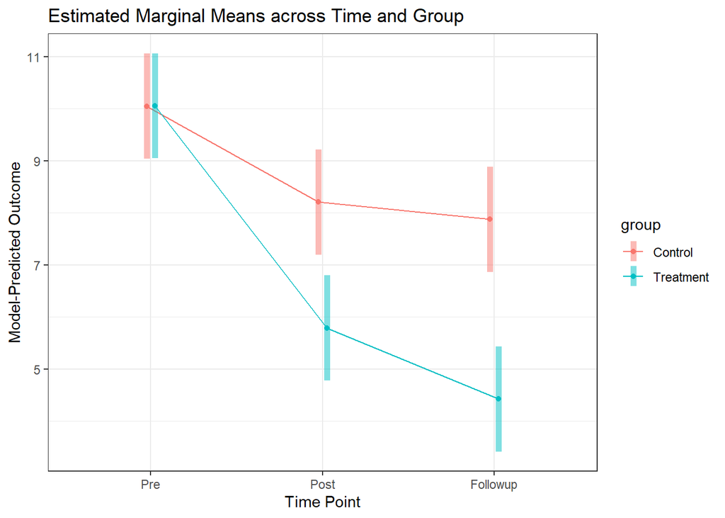

```r
emmip(model_f5, group ~ time, CIs = TRUE, engine = "ggplot") +
  theme_bw() +
  labs(
    title = "Estimated Marginal Means across Time and Group",
    y = "Model-Predicted Outcome",
    x = "Time Point"
  )
```

## 5.13. Applying This to a Model You Already Have: Section 3 Revisited

Everything above works exactly the same way on the mixed-factorial models we already built in Section 3 – indeed, `mod3`/`mod3_sum` are the very models we used to demonstrate the coding issue at the start of this section:

```r
anova(mod3_sum)
```

|  | Sum Sq | Mean Sq | NumDF | DenDF | F value | Pr(>F) |
| --- | --- | --- | --- | --- | --- | --- |
| age_group | 0.24387434 | 0.24387434 | 1 | 38 | 47.176032 | 3.706668e-08 |
| condition | 0.28195510 | 0.14097755 | 2 | 76 | 27.271263 | 1.181245e-09 |
| age_group:condition | 0.05667469 | 0.02833734 | 2 | 76 | 5.481689 | 5.972183e-03 |

```r
# note the statistically significant interaction term, justifying follow-up
# post-hoc tests
emm3 <- emmeans(mod3_sum, ~ age_group * condition)
# Estimated Marginal Means for each cell:
emm3
```

```
##  age_group condition emmean     SE df lower.CL upper.CL
##  OA        A          0.700 0.0267 63    0.647    0.753
##  YA        A          0.985 0.0267 63    0.932    1.038
##  OA        B          0.870 0.0267 63    0.816    0.923
##  YA        B          1.052 0.0267 63    0.999    1.105
##  OA        C          0.789 0.0267 63    0.735    0.842
##  YA        C          0.997 0.0267 63    0.944    1.051
##
## Degrees-of-freedom method: kenward-roger
## Confidence level used: 0.95
```

```r
# Simple effects: is the Age Group difference present in every condition,
# or only some of them?
pairs(emmeans(mod3_sum, ~ age_group | condition))
```

```
## condition = A:
##  contrast estimate     SE df t.ratio p.value
##  OA - YA    -0.285 0.0377 63  -7.560  <.0001
##
## condition = B:
##  contrast estimate     SE df t.ratio p.value
##  OA - YA    -0.183 0.0377 63  -4.844  <.0001
##
## condition = C:
##  contrast estimate     SE df t.ratio p.value
##  OA - YA    -0.208 0.0377 63  -5.530  <.0001
##
## Degrees-of-freedom method: kenward-roger
```

This shows that Older Adults are reliably slower than Younger Adults in every one of the three conditions (all three simple-effect comparisons are significant), which is a useful, concrete finding in its own right, and a good sanity check that the significant Age Group x Condition interaction we found in Section 3 reflects a difference in the *size* of the age gap across conditions, not a reversal of it.

## Summary

- `summary()` and `anova()`/`car::Anova()` answer different questions – individual, coding-dependent coefficients versus omnibus, term-level tests – and it’s worth knowing which one you’re looking at.
- `lmerTest::anova()`’s omnibus tests are invariant to how you code *categorical* predictors, in balanced and unbalanced designs alike; `car::Anova(type="III")` is not, and needs sum (or polynomial) contrasts to agree with it once an interaction is present.
- Centering matters even more, and for a different reason: any *continuous* covariate involved in an interaction can distort the omnibus test of the other, lower-order term it interacts with, in *any* of these functions, simply based on where its zero point happens to sit. This can’t be fixed by a contrasts option – it has to be handled explicitly in your data (as `year.0`/`year.c`/`time.c` already do throughout this repository).
- Both problems have the same root cause: a Type III test of a lower-order term, in the presence of an interaction, is implicitly a test “at” some reference point, and that reference point is set by your coding/centering choices whether you intend it or not.
- `emmeans` (for means and factor-level comparisons) and `emtrends` (for the slope of a continuous predictor) sidestep this entirely, by making you name the reference point (or the averaging scheme) explicitly – which is why they give identical answers regardless of coding or centering, even when the omnibus test built on the same model does not.
- Use the `|` operator inside the reference-grid formula (e.g., `~ group | time`) to request **simple effects** – comparisons within one factor, holding another factor fixed – and always choose and report a multiple-comparison adjustment that matches how many comparisons you are actually making.
- Custom contrasts let you test a specific, pre-registered hypothesis directly, but the weight vector must match the reference grid’s cell order exactly – print the grid and check your arithmetic before trusting the result.

## References

Hoffmann, S., Lemster, S., Collins, G., Hapfelmeier, A., Heinze, G., Mayr, A., … & Boulesteix, A. L. (2026). When to Adjust for Multiple Testing: A Unifying Guiding Principle. *Biometrical Journal*, 68(4), e70148. https://doi.org/10.1002/bimj.70148

Kenward, M. G., & Roger, J. H. (1997). Small Sample Inference for Fixed Effects from Restricted Maximum Likelihood. *Biometrics, 53*(3), 983. https://doi.org/10.2307/2533558

Lenth, R. V. (2016). Least-Squares Means: The R Package lsmeans. *Journal of Statistical Software*, 69(1), 1-33. https://doi.org/10.18637/jss.v069.i01

Rothman, K. J. (1990). No adjustments are needed for multiple comparisons. *Epidemiology*, 1(1), 43-46. https://www.ovid.com/jnls/epidem/toc/1990/01000

Schad, D. J., Vasishth, S., Hohenstein, S., & Kliegl, R. (2020). How to capitalize on a priori contrasts in linear (mixed) models: A tutorial. *Journal of Memory and Language, 110*, 104038. https://doi.org/10.1016/j.jml.2019.104038

Venables, W. N., & Ripley, B. D. (1997). *Modern Applied Statistics with S-PLUS*. Springer.